# Informe de Estadística Espacial Pecuaria

Análisis Geoespacial

2026-04-20

## 1. Introducción y Preparación

Este informe presenta el análisis espacial de la producción pecuaria en el Perú, analizando la productividad por productor, la especialización regional (ej. Charqui) y la variación de producción entre los años 2021 y 2024.

```r
############################################################
# LIBRERÍAS
############################################################
library(sf)
library(arrow)
library(dplyr)
library(stringr)
library(ggplot2)
library(tidyr)
library(forcats)
```

## 2. Carga de Datos y Limpieza Geoespacial

Se utiliza el shapefile provincial del INEI para los límites geográficos y archivos con formato `parquet` procesados vía Apache Arrow para los datos transaccionales, optimizando así el rendimiento.

```r
############################################################
# SHAPEFILE
############################################################
mapa <- st_read("C:/Users/noel1/Desktop/ESTADISTICA ESPACIAL/Provincial INEI 2023 geogpsperu SuyoPomalia/Provincial INEI 2023 geogpsperu SuyoPomalia.shp", quiet = TRUE)

mapa <- mapa %>%
  mutate(DEPARTAMEN = str_trim(DEPARTAMEN))

############################################################
# DICCIONARIO ESTÁTICO: NOMBREDD sucio → DEPARTAMEN oficial
############################################################
dic_dep <- tribble(
  ~NOMBREDD,                  ~DEPARTAMEN,
  "AMAZONAS",                 "AMAZONAS",
  "ANCASH",                   "ANCASH",
  "APURIMAC",                 "APURIMAC",
  "AREQUIPA",                 "AREQUIPA",
  "AYACUCHO",                 "AYACUCHO",
  "CAJAMARCA",                "CAJAMARCA",
  "CALLAO",                   "CALLAO",
  "CUSCO",                    "CUSCO",
  "HUANCAVELICA",             "HUANCAVELICA",
  "HUANUCO",                  "HUANUCO",
  "ICA",                      "ICA",
  "JUNIN",                    "JUNIN",
  "LA LIBERTAD",              "LA LIBERTAD",
  "LAMBAYEQUE",               "LAMBAYEQUE",
  "LIMA",                     "LIMA",
  "LORETO",                   "LORETO",
  "MADRE DE DIOS",            "MADRE DE DIOS",
  "MOQUEGUA",                 "MOQUEGUA",
  "PASCO",                    "PASCO",
  "PIURA",                    "PIURA",
  "PUNO",                     "PUNO",
  "SAN MARTIN",               "SAN MARTIN",
  "TACNA",                    "TACNA",
  "TUMBES",                   "TUMBES",
  "UCAYALI",                  "UCAYALI",
  "AMAZON",                   "AMAZONAS",
  "AREQUI",                   "AREQUIPA",
  "AYACUC",                   "AYACUCHO",
  "CAJAMA",                   "CAJAMARCA",
  "HUANCA",                   "HUANCAVELICA",
  "LA LIB",                   "LA LIBERTAD",
  "LAMBAY",                   "LAMBAYEQUE",
  "MADRE ",                   "MADRE DE DIOS",
  "MOQUEG",                   "MOQUEGUA",
  "SAN MA",                   "SAN MARTIN",
  "UCAYAL",                   "UCAYALI",
  "MADRE",                    "MADRE DE DIOS",
  "APUR\u00cdMAC",            "APURIMAC",
  "APUR\u00cd",               "APURIMAC",
  "HU\u00c1NUCO",             "HUANUCO",
  "HU\u00c1NU",               "HUANUCO",
  "JUN\u00cdN",               "JUNIN",
  "SAN MART\u00cdN",          "SAN MARTIN",
  "HUANCAVELICA",             "HUANCAVELICA",
  "APUR\u00c3\u008dMAC",      "APURIMAC",
  "APUR\u00c3\u008d",         "APURIMAC",
  "HU\u00c3\u0081NUCO",       "HUANUCO",
  "HU\u00c3\u0081NU",         "HUANUCO",
  "JUN\u00c3\u008dN",         "JUNIN",
  "SAN MART\u00c3\u008dN",    "SAN MARTIN",
  "HUANC\u00c3AVELICA",       "HUANCAVELICA",
  "HUANCA\u00c3VELICA",       "HUANCAVELICA"
)

############################################################
# PARQUET Y ETL
############################################################
files <- list.files(
  "C:/Users/noel1/Desktop/ESTADISTICA ESPACIAL/",
  pattern = "data_part_.*\\.parquet$",
  full.names = TRUE
)

ds <- open_dataset(files) %>%
  rename(ANIO = `ï»¿ANIO`)

vars_p420 <- names(ds)[grepl("^P420", names(ds))]
vars_p419 <- names(ds)[grepl("^P419", names(ds))]

ds_sel <- ds %>%
  select(
    ANIO, CCDD, NOMBREDD,
    LONGITUD, LATITUD,
    FACTOR, RESFIN,
    all_of(vars_p419),
    all_of(vars_p420)
  )

# RECUPERACIÓN ESPACIAL FALLBACK (TryCatch)
fix_geo_raw <- tryCatch({
  ds_sel %>%
    mutate(
      NOMBREDD = as.character(NOMBREDD),
      LONGITUD = as.character(LONGITUD),
      LATITUD  = as.character(LATITUD)
    ) %>%
    mutate(NOMBREDD_trim = str_trim(NOMBREDD)) %>%
    filter(is.na(NOMBREDD_trim) | NOMBREDD_trim %in% c("", " ")) %>%
    select(CCDD, LONGITUD, LATITUD) %>%
    distinct() %>%
    collect() %>%
    mutate(
      LONGITUD = suppressWarnings(as.numeric(str_trim(LONGITUD))),
      LATITUD  = suppressWarnings(as.numeric(str_trim(LATITUD)))
    ) %>%
    filter(!is.na(LONGITUD), !is.na(LATITUD))
}, error = function(e) {
  tibble(CCDD = character(), LONGITUD = numeric(), LATITUD = numeric())
})

if (is.data.frame(fix_geo_raw) && nrow(fix_geo_raw) > 0) {
  fix_geo_sf <- st_as_sf(
    fix_geo_raw, coords = c("LONGITUD", "LATITUD"),
    crs = st_crs(mapa)
  )
  fix_geo <- st_join(fix_geo_sf, mapa %>% select(DEPARTAMEN), left = TRUE) %>%
    st_drop_geometry() %>%
    select(CCDD, DEPARTAMEN) %>%
    distinct() %>% filter(!is.na(DEPARTAMEN))
} else {
  fix_geo <- tibble(CCDD = character(), DEPARTAMEN = character())
}

limpiar_dep <- function(df) {
  df %>%
    mutate(NOMBREDD = str_trim(NOMBREDD)) %>%
    left_join(dic_dep, by = "NOMBREDD") %>%
    { if ("CCDD" %in% names(.))
      left_join(., fix_geo, by = "CCDD") %>%
        mutate(DEPARTAMEN = coalesce(DEPARTAMEN.x, DEPARTAMEN.y)) %>%
        select(-any_of(c("DEPARTAMEN.x", "DEPARTAMEN.y")))
      else . } %>%
    mutate(DEPARTAMEN = if_else(
      is.na(DEPARTAMEN) | DEPARTAMEN == "",
      if_else(NOMBREDD == "", NA_character_, NOMBREDD),
      DEPARTAMEN
    ))
}

ds_clean <- ds_sel %>%
  mutate(
    RESFIN = str_trim(RESFIN),
    RESFIN = if_else(RESFIN == "", NA, RESFIN),
    RESFIN = cast(RESFIN, int32())
  ) %>%
  filter(RESFIN == 1) %>%
  mutate(
    NOMBREDD = str_trim(NOMBREDD),
    P419_NOM = str_trim(P419_NOM),
    P419_NOM = if_else(P419_NOM == "", NA, P419_NOM),
    P419_NOM = toupper(P419_NOM),
    P420_EQUIV = str_trim(P420_EQUIV),
    P420_EQUIV = if_else(P420_EQUIV == "", NA, P420_EQUIV),
    P420_CANT_ENT = str_trim(P420_CANT_ENT),
    P420_CANT_ENT = if_else(P420_CANT_ENT == "", NA, P420_CANT_ENT),
    P420_CANT_DEC = str_trim(P420_CANT_DEC),
    P420_CANT_DEC = if_else(P420_CANT_DEC == "", NA, P420_CANT_DEC),
    FACTOR = str_trim(FACTOR),
    FACTOR = if_else(FACTOR == "", NA, FACTOR)
  ) %>%
  filter(!is.na(P419_NOM)) %>%
  mutate(
    P420_EQUIV = if_else(
      str_starts(P420_EQUIV, "\\."),
      paste0("0", P420_EQUIV),
      P420_EQUIV
    )
  ) %>%
  mutate(
    P420_EQUIV = cast(P420_EQUIV, float64()),
    P420_CANT_ENT = cast(P420_CANT_ENT, float64()),
    P420_CANT_DEC = cast(P420_CANT_DEC, float64()),
    FACTOR = cast(FACTOR, float64())
  )

ds_trans <- ds_clean %>%
  mutate(
    cantidad = coalesce(P420_CANT_ENT, 0) + coalesce(P420_CANT_DEC, 0) / 100,
    kg = cantidad * coalesce(P420_EQUIV, 1),
    FACTOR = coalesce(FACTOR, 1),
    kg_pond = kg * FACTOR
  )
```

## 3. Insight 1: Productividad Global

Análisis del rendimiento (volumen de extracción en kilogramos de derivados pecuarios) por unidad de producción encuestada en cada departamento.

### Mapa Coroplético

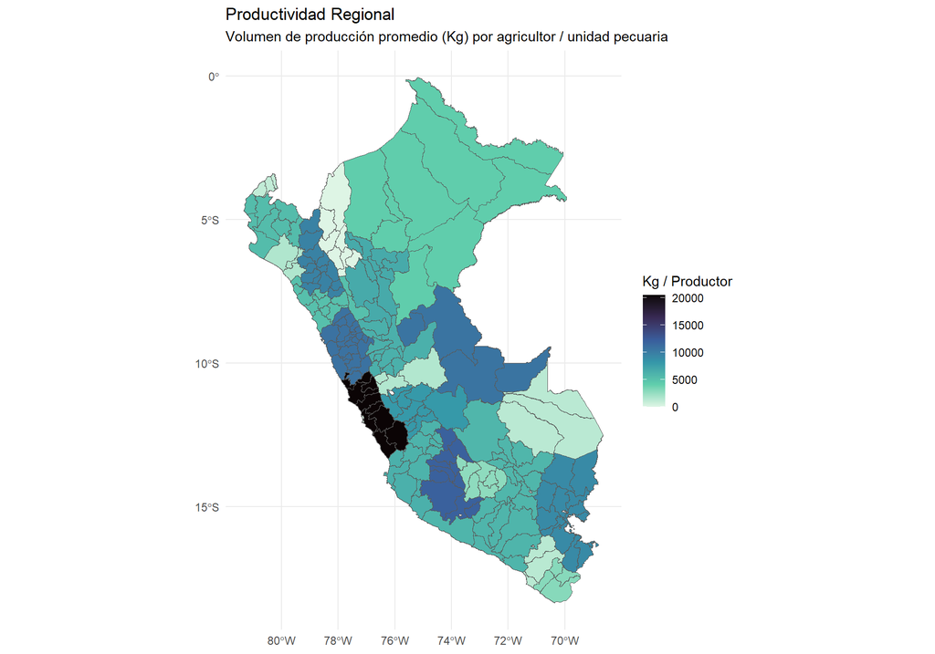

```r
ggplot(mapa_productividad) +
  geom_sf(aes(fill = kg_por_productor)) +
  scale_fill_viridis_c(option = "mako", na.value = "grey90", direction = -1) +
  theme_minimal() +
  labs(
    title = "Productividad Regional",
    subtitle = "Volumen de producción promedio (Kg) por agricultor / unidad pecuaria",
    fill = "Kg / Productor"
  ) +
  theme(legend.position = "right")
```

### Gráfico de Ranking

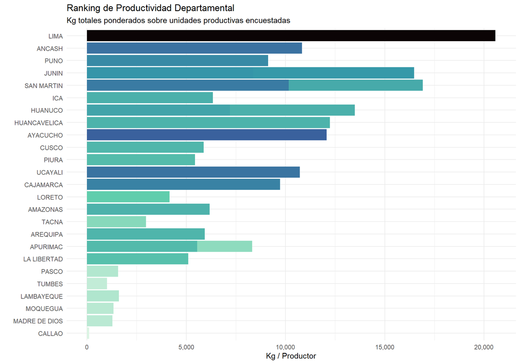

```r
data_productividad %>%
  limpiar_dep() %>%
  filter(!is.na(DEPARTAMEN)) %>%
  mutate(DEP = fct_reorder(DEPARTAMEN, kg_por_productor)) %>%
  ggplot(aes(x = kg_por_productor, y = DEP, fill = kg_por_productor)) +
  geom_col(show.legend = FALSE) +
  scale_fill_viridis_c(option = "mako", direction = -1) +
  scale_x_continuous(labels = scales::comma) +
  theme_minimal(base_size = 11) +
  labs(
    title    = "Ranking de Productividad Departamental",
    subtitle = "Kg totales ponderados sobre unidades productivas encuestadas",
    x        = "Kg / Productor",
    y        = ""
  )
```

## 4. Insight 2: Clúster de “CHARQUI”

El Charqui es un derivado cárnico altamente identitario. Analizaremos su nivel de concentración en el territorio nacional.

### Mapa de Especialización

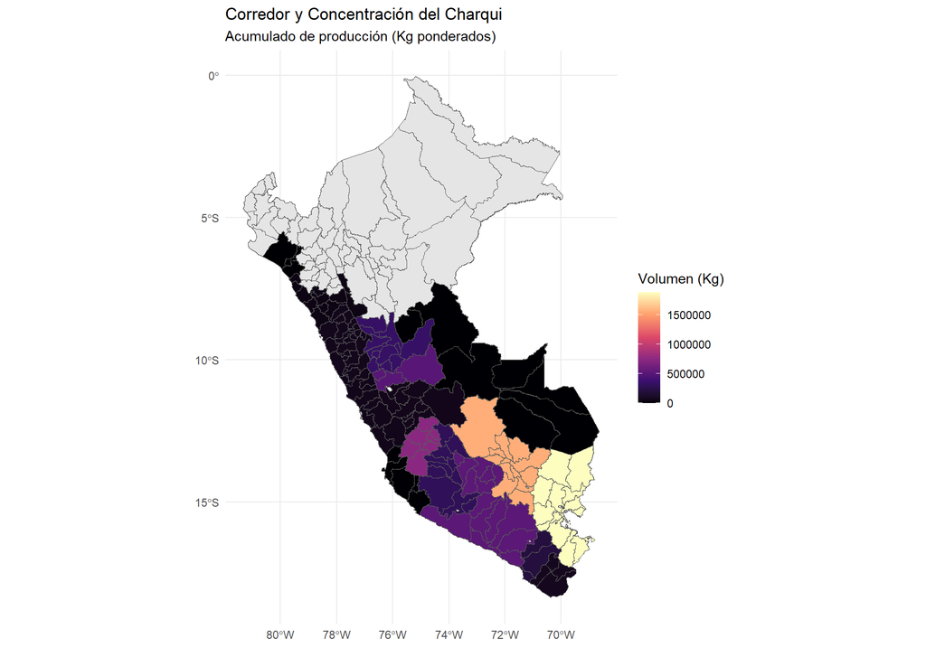

```r
ggplot(mapa_especializacion) +
  geom_sf(aes(fill = kg_especifico)) +
  scale_fill_viridis_c(option = "magma", na.value = "grey90") +
  theme_minimal() +
  labs(
    title = "Corredor y Concentración del Charqui",
    subtitle = "Acumulado de producción (Kg ponderados)",
    fill = "Volumen (Kg)"
  )
```

### Volúmenes de Producción

Los departamentos líderes en procesamiento de charqui:

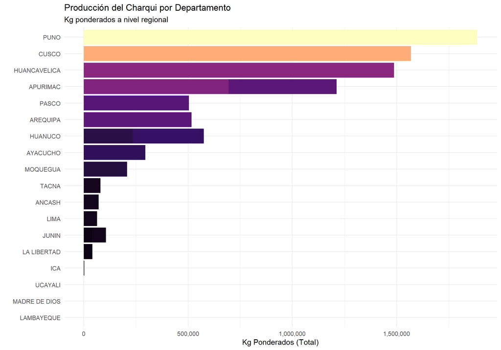

```r
data_especializacion %>%
  limpiar_dep() %>%
  filter(!is.na(DEPARTAMEN), !is.na(kg_especifico)) %>%
  mutate(DEP = fct_reorder(DEPARTAMEN, kg_especifico)) %>%
  ggplot(aes(x = kg_especifico, y = DEP, fill = kg_especifico)) +
  geom_col(show.legend = FALSE) +
  scale_fill_viridis_c(option = "magma") +
  scale_x_continuous(labels = scales::comma) +
  theme_minimal(base_size = 11) +
  labs(
    title    = "Producción del Charqui por Departamento",
    subtitle = "Kg ponderados a nivel regional",
    x        = "Kg Ponderados (Total)",
    y        = ""
  )
```

## 5. Insight 3: Dinámica y Evolución (2021 vs 2024)

¿En qué departamentos se experimentó contracción de la producción total general y en cuáles un crecimiento en el salto interanual analizado?

### Crecimiento y Contracción Geográfica

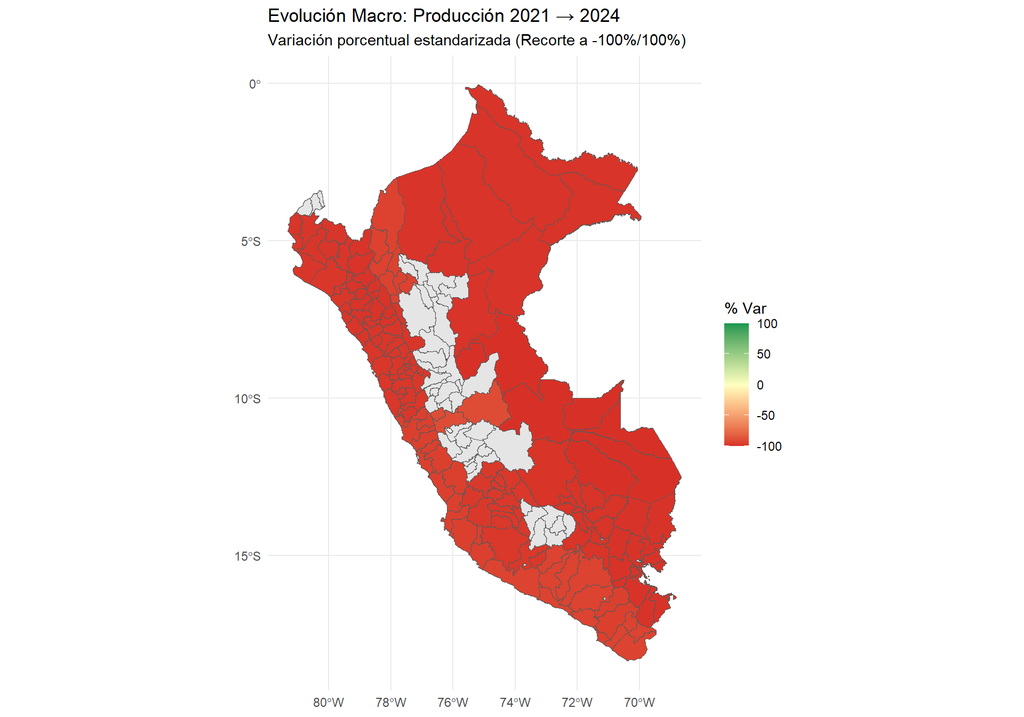

```r
ggplot(mapa_temporal) +
  geom_sf(aes(fill = variacion_pct)) +
  scale_fill_gradient2(
    low = "#d73027", mid = "#ffffbf", high = "#1a9850",
    midpoint = 0, na.value = "grey90",
    limits = c(-100, 100), oob = scales::squish
  ) +
  theme_minimal() +
  labs(
    title = "Evolución Macro: Producción 2021 → 2024",
    subtitle = "Variación porcentual estandarizada (Recorte a -100%/100%)",
    fill = "% Var"
  )
```

### Desglose de Variación

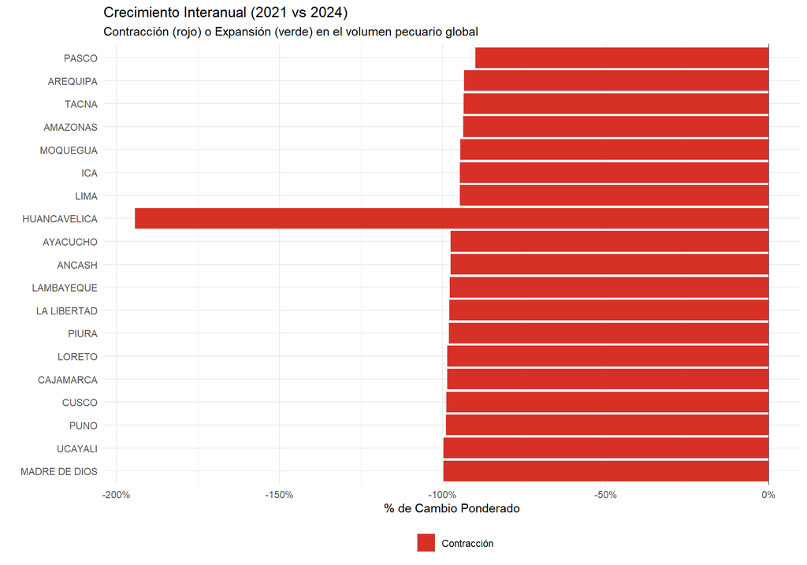

```r
data_temporal %>%
  limpiar_dep() %>%
  filter(!is.na(DEPARTAMEN), !is.na(variacion_pct)) %>%
  mutate(
    DEP       = fct_reorder(DEPARTAMEN, variacion_pct),
    direccion = if_else(variacion_pct >= 0, "Crecimiento", "Contracción")
  ) %>%
  ggplot(aes(x = variacion_pct, y = DEP, fill = direccion)) +
  geom_col() +
  geom_vline(xintercept = 0, linewidth = 0.5, colour = "grey40") +
  scale_fill_manual(values = c("Crecimiento" = "#1a9850", "Contracción" = "#d73027")) +
  scale_x_continuous(labels = scales::percent_format(scale = 1)) +
  theme_minimal(base_size = 11) +
  labs(
    title    = "Crecimiento Interanual (2021 vs 2024)",
    subtitle = "Contracción (rojo) o Expansión (verde) en el volumen pecuario global",
    x        = "% de Cambio Ponderado",
    y        = "",
    fill     = ""
  ) +
  theme(legend.position = "bottom")
```

## 6. Panorama Consolidado de Volúmenes

Finalmente, este es el consolidado del volumen bruto de producción en la historia de los datos analizados, uniendo todos los departamentos.

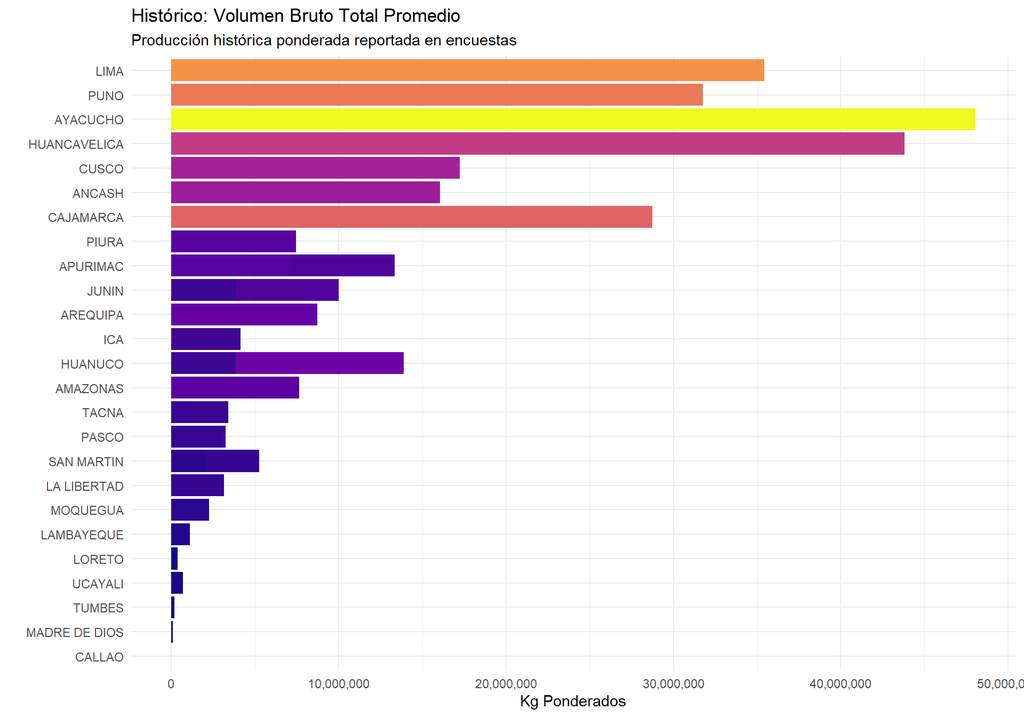

```r
data_dep <- ds_trans %>%
  group_by(NOMBREDD) %>%
  summarise(
    total_kg_pond = sum(kg_pond, na.rm = TRUE),
    productores = n()
  ) %>%
  collect() %>%
  mutate(NOMBREDD = str_trim(NOMBREDD))

data_dep %>%
  limpiar_dep() %>%
  filter(!is.na(DEPARTAMEN)) %>%
  mutate(DEP = fct_reorder(DEPARTAMEN, total_kg_pond)) %>%
  ggplot(aes(x = total_kg_pond, y = DEP, fill = total_kg_pond)) +
  geom_col(show.legend = FALSE) +
  scale_fill_viridis_c(option = "plasma") +
  scale_x_continuous(labels = scales::comma) +
  theme_minimal(base_size = 11) +
  labs(
    title    = "Histórico: Volumen Bruto Total Promedio",
    subtitle = "Producción histórica ponderada reportada en encuestas",
    x        = "Kg Ponderados",
    y        = ""
  )
```

*Análisis automatizado en R con dplyr, arrow, sf y ggplot2.*